# 第12回 経験から先を読む

経済プログラミング特論II

第12回・開店 47 日目

経験から先を読む

売れなくても、次の客の分を足す

経済プログラミング特論II

第12回・開店 47 日目 — Topic01

行動価値の表

状態ごとに分けても、今の売上だけでは届かない

## うちの店と 4 段の店長

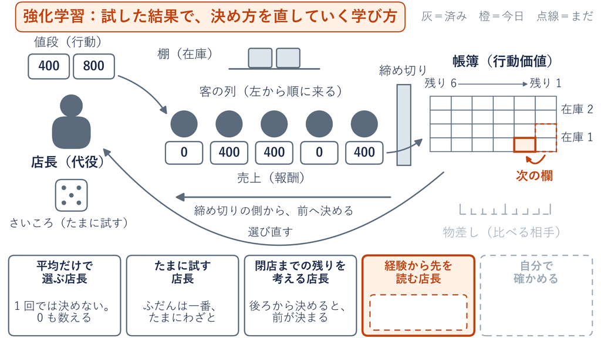

| 1 帳簿を状態ごとに | 2 売れなかった 800 円 | 3 何日でたどり着くか | 4 上達の測り方 |
| --- | --- | --- | --- |
| 写経・実行・演習 1 | 写経・実行・演習 2 | 写経・演習 3 | 実行・写経・演習 4 |

今日の相談：仕組みを書かずに、記録だけで、先を考えた値段を学べるか

## 店の設定と 2 人の店長

答え合わせは、割合と移り方を決めた計算機の中の店で

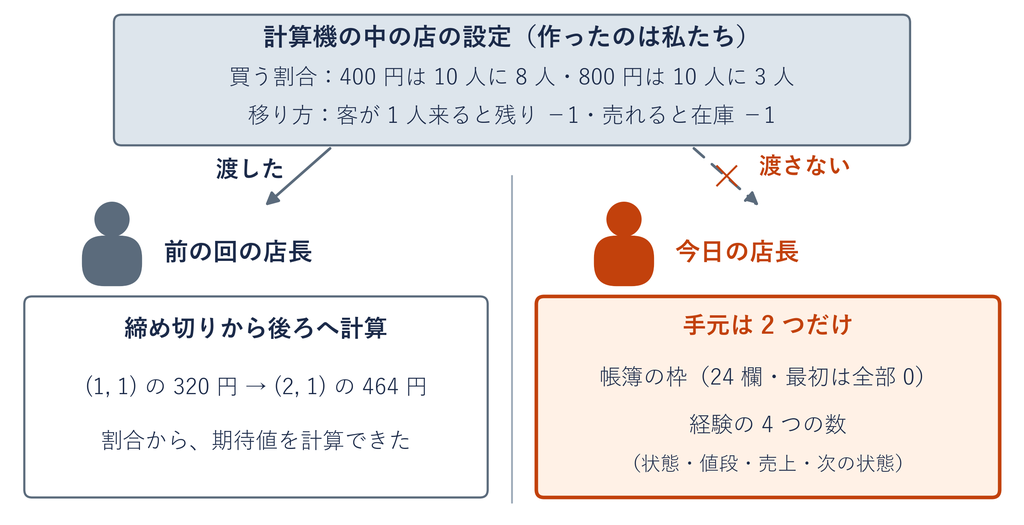

今日の店長は期待値を計算しない  
来た客の結果の平均を、帳簿に書いて直す

## 前の回と同じ輪、差し替えるのは 1 か所

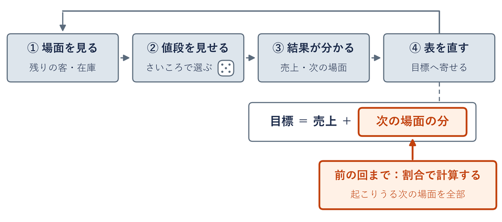

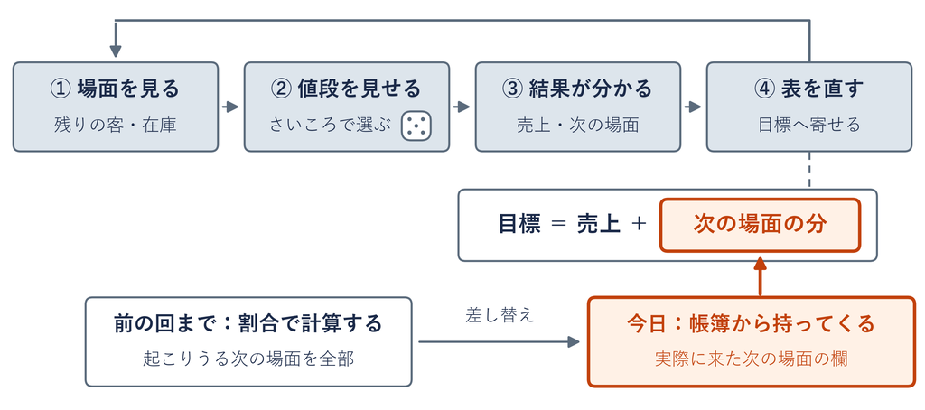

記録の集め方は同じ  
違うのは、次の場面の分を、割合で計算するか、帳簿から持ってくるか

2 つは混ぜて使うこともできる

## 前の回の合言葉とさいころ

前の回の合言葉：後ろから決めると、前が決まる

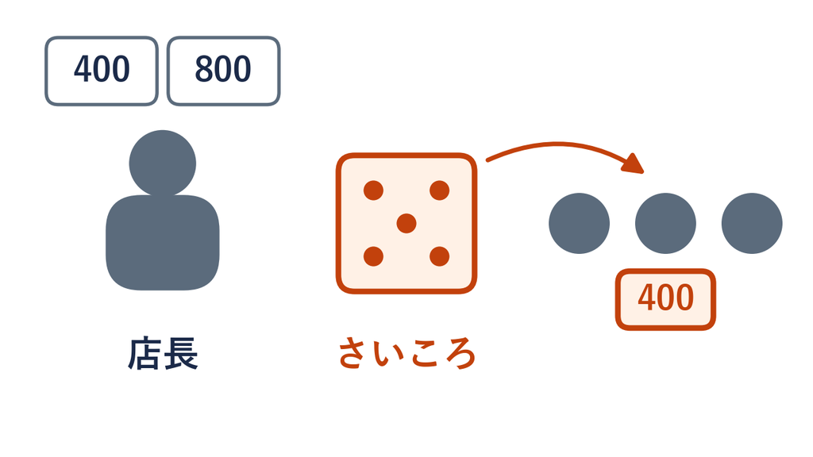

前の前の回の合言葉：**ふだんは一番、たまにわざと**  
今日の店長も、同じさいころ・同じ直し方で学ぶ

## 残り 2 人・在庫 1 の逆算

いまの状態（残りの人数, 在庫）

(2, 1)

前の回の店長の計算（店の設定を知っていたから出せた）

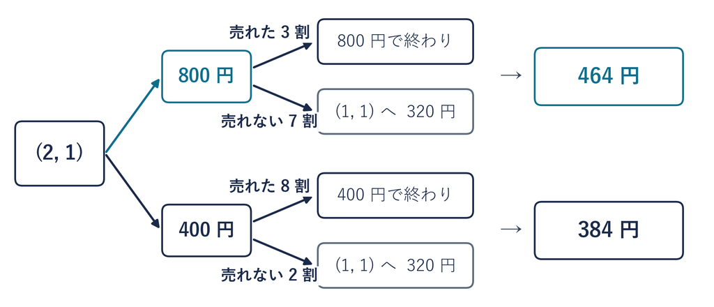

**800 円の期待値**：464 円（0.3 × 800 ＋ 0.7 × 320 ＝ 464）

**400 円の期待値**：384 円 → 前の回の答えは 800 円

**価値**前の回の表の数。割合から計算した、締め切りまでの売上の期待値

## 状態ごとの帳簿で選ぶ (2, 1) の値段

**学生の帳簿**：状態ごと・値段ごとに分けた。直し方は、たまに試すやり方のまま

この店なら、記録を伸ばして 5000 日学ばせれば  
(2, 1) は 800 円を選ぶようになるか

- **①** なる
- **②** ならない

動画を止めて、①・②から1つ選んで、少し考えてから再生

## 経験の 1 件

いまの状態（残りの人数, 在庫）

(6, 2)→ (5, 1)

記録から分かるのは、見せた値段と、売れたかどうかと、そのあとの状態だけ

**経験の 1 件**（状態, 値段, 売上, 次の状態）の 4 つを 1 組にした記録

例：学んで 1 日目の 1 人目 ＝ ((6, 2), 400 円, 400 円, (5, 1))

店の設定（割合・移り方）を持つのは計算機の中の店だけ  
店長に届くのは経験の 1 件だけ

## 学生の帳簿：帳簿を分けてからの 4 日

いまの状態（残りの人数, 在庫）

(6, 2)

うちの店の客の並び（seed 42）で 4 日。経験を 1 件ずつ、その状態の欄に書く

**分けてから 1〜3 日目**：(6, 2) 400 ○ → (5, 1) 400 ○ → 売り切れ（毎日同じ・○ 売れた・✕ 売れない）

**4 日目**：(6, 2) 800 ✕ → (5, 2) 400 ○ → (4, 1) 800 ✕ → (3, 1) 400 ○ → 売り切れ

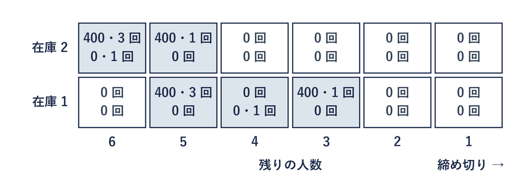

6 欄を直した（うち 2 欄は、試した 800 円が売れず 0）。18 欄は未経験

## 行動価値の表

**状態ごと・値段ごとに分けた、売上の平均の帳簿**

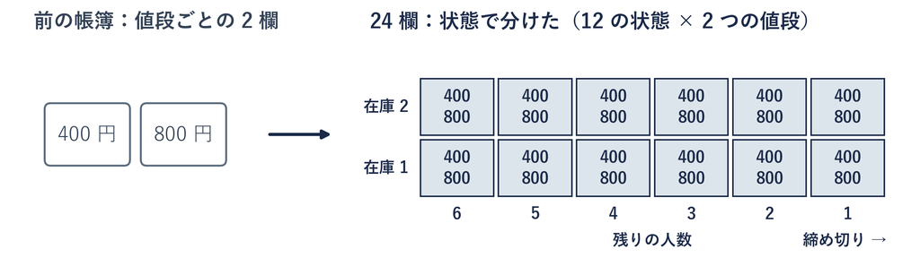

**行動価値の表**状態と値段の組ごとに、その値段を見せたときの売上の平均を書いた表

**直し方（前のまま）**：新しい平均 ＝ 古い平均 ＋（今回の売上 − 古い平均）÷ その欄の回数

**選び方（前のまま）**：たまに試し、ほかはその状態の帳簿が大きいほう（同じなら 400 円）

## 1 日の営業

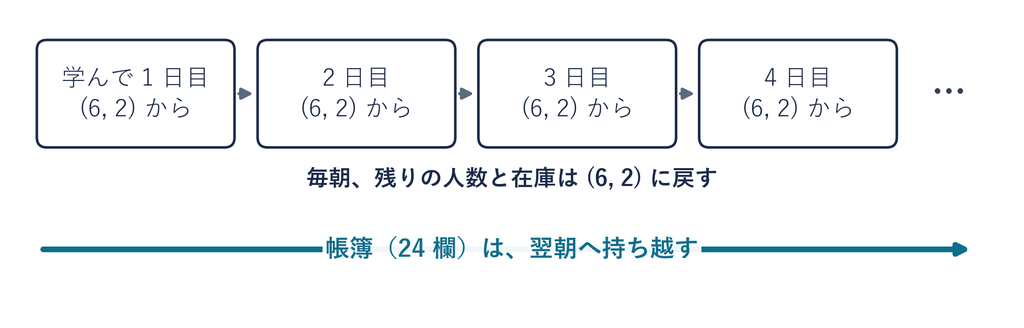

**1 日**：毎朝 (6, 2) から、締め切りか売り切れで終わるまで  
帳簿は翌日へ持ち越す

## 学んで 5000 日の値段の表

いまの状態（残りの人数, 在庫）

(残りの人数, 在庫)

今度は、学生の帳簿のつけ方を、計算機の中の代役に 5000 日続けさせる  
代役の名前：**今の売上だけで帳簿をつける店長**  
（割合は使わない。手元は経験の 4 つの数だけ）  
前の回の店長から変わったのは手元だけ。直し方はまだ前のまま

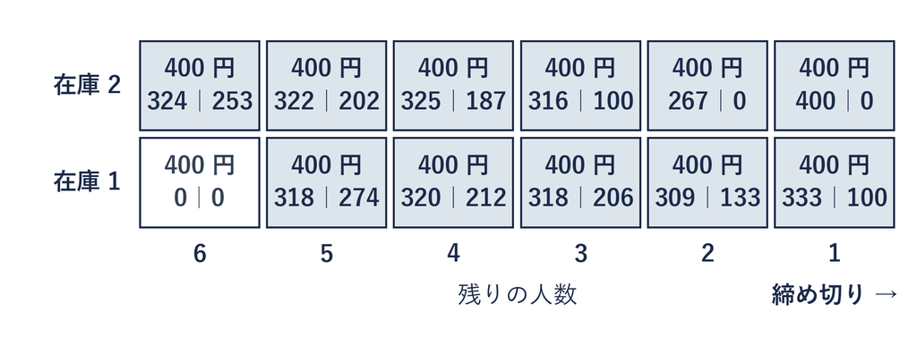

うちの店の客の並び（seed 42）では全欄 400 円。  
入口の答えは ②（ならない）  
(6, 2) も 324 円 ＞ 253 円（4487 回・513 回）

## 前の回の表との並べ

いまの状態（残りの人数, 在庫）

(残りの人数, 在庫)

[figure not shown]

出てくる 11 の状態のうち、8 つで違う

帳簿の数は、その 1 人ぶんの売上の平均。1 人ぶんの期待値は、400 円なら 320 円  
800 円なら 240 円。1 人ぶんだけなら、どの状態でも 400 円が上。  
前の表の数は、締め切りまでの期待値

## 帳簿を作る写経

```python
q = {}                              # 帳簿：状態を引くと 2 つの数が出る表
for rest in range(1, 7):            # 残りの人数：1〜6 人
    for stock in [1, 2]:            # 在庫：1 個か 2 個
        q[(rest, stock)] = [0, 0]   # 欄（400 円, 800 円）を 0 で作る
print(q)
```

| 行 | 部品 | 中身 |
| --- | --- | --- |
| 1 | **① 空の帳簿** | `{}` は空の辞書。状態を引くと欄が出る表 |
| 2〜3 | **② 2 重の for** | 前に出てきた形のまま。12 の状態を順に回る |
| 4 | **③ 欄を作る** | 状態の組 (rest, stock) を引く札にして、 400 円・800 円の 2 つの数を 0 で置く |
| 5 | **④ 表示** | 帳簿を丸ごと出す。12 の状態 × 2 ＝ 24 個の 0 |

※ 前に出てきた 2 重の for の `print((rest, stock))` の行を、欄を作る 1 行に替えただけ

## 帳簿の写経と実行

1. **＋ コード**で足したセルに  
   p.15 の 5 行を写して実行
2. 出力の 12 の組が  
   全部 [0, 0] かを見る
3. 下の【そのまま実行】は  
   写さずに ▶ だけ
4. 6 行の出力が  
   全部 400 400 かを見る

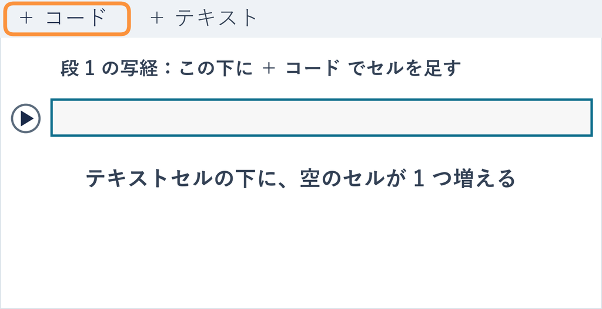

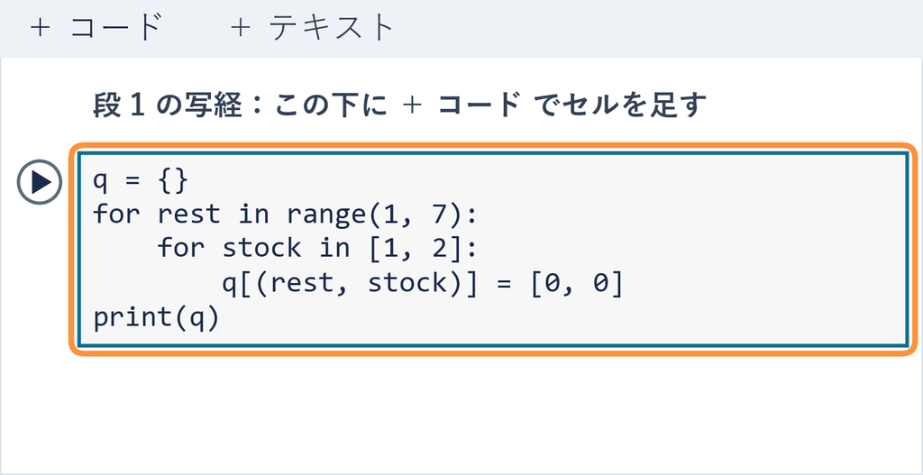

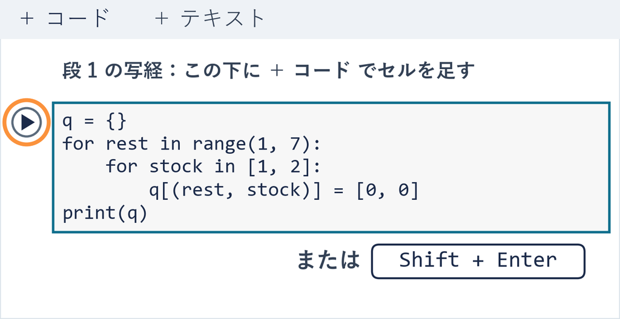

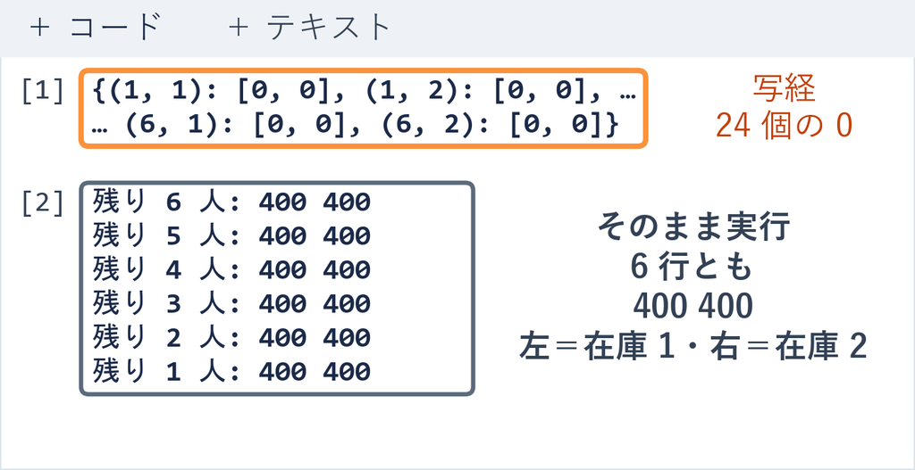

⏸ PAUSE 動画を止めて $4$ 分。2 つのセルの出力が出たら再生に戻る

## 演習1 (2, 1) の帳簿

前の回の (2, 1) の期待値 400 円 384・800 円 464

演習 1

(2, 1) の帳簿でも、800 円が上になるか

```python
q = learn(5000)
st = (6, 2)                                # ← ここを書き換える
print(st, "400 円:", round(q[st][0]), " 800 円:", round(q[st][1]))
```

1. **書き換える**：**＋ コード**で足したセルに 3 行を写し  
   2 行目の (6, 2) を (2, 1) に
2. **確かめる**：p.13 で見た数が、自分の手でも出るか  
   （800 円は 上／上でない）
3. **終わり**：1 行が出たら、答え欄に書く  
   （上か上でないかと、2 つの数）

⏸ PAUSE 動画を止めて $5$ 分。答え欄に書けたら再生に戻る

## 演習1の答え

| (2, 1) の帳簿 | 400 円 | 800 円 | 800 円を見せた回数 |
| --- | --- | --- | --- |
| 前の回の期待値 （割合から計算） | 384 | 464 | — |
| 今の売上だけで帳簿を つける店長 | 309 | 133 | 12 回 |

- **答え**：上でない。309 円 ＞ 133 円で、選ぶのは 400 円
- **理由**：帳簿の数は、その 1 人ぶんの売上の平均だけ

売れなかった 800 円は 0 円と数えるので、464 円には届かない

## まとめ

疑問 状態ごとに帳簿を分けて、  
今の売上を平均すれば、前の回の表に届くか

回答 届かない  
今の売上だけの平均では、記録を伸ばしても、  
どの欄も安いほうが上になる

次の疑問 (2, 1) の 800 円の欄は、前の表とどこが違うのか

経済プログラミング特論II

第12回・開店 47 日目 — Topic02

更新目標

売れなかった 800 円にも、次の客の分を書く

## 売れなかった 800 円の行き先

いまの状態（残りの人数, 在庫）

(2, 1)

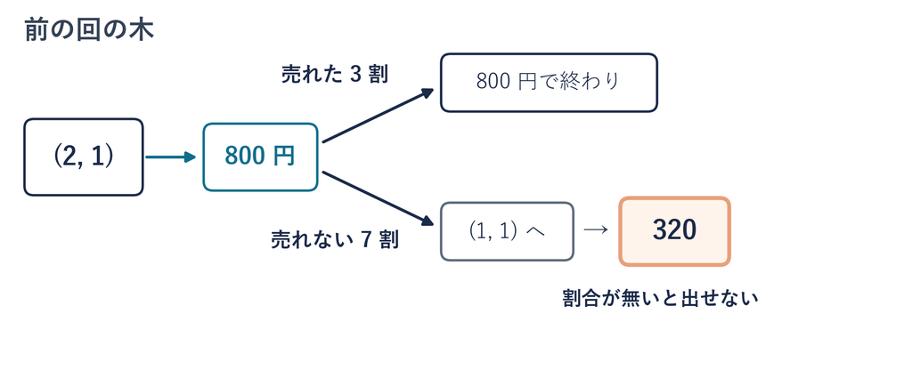

この店なら、(2, 1) で 800 円が売れなかったとき  
800 円の欄は、何に向けて直すか（向かう先を**目標**と呼ぶ）

割合を渡さない店長は、この 320 の場所に何を置けるか

## 帳簿に書きたいのは、締め切りまでの売上

**今の売上だけの帳簿**：今回の売上の平均（数の線で、今回の売上へ寄せた）

**前の回の表**：締め切りまでの売上の期待値（464 は、2 人目の 320 も入れた数）

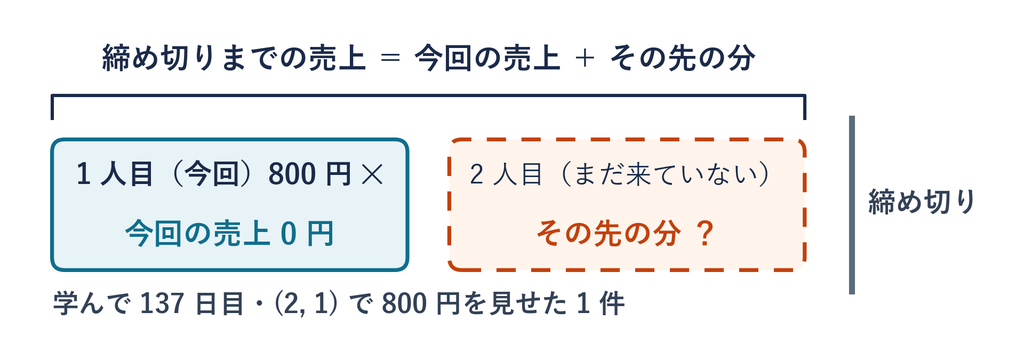

まだ来ていない 2 人目の分を、何で埋めるか

## 売れなかった 800 円の目標

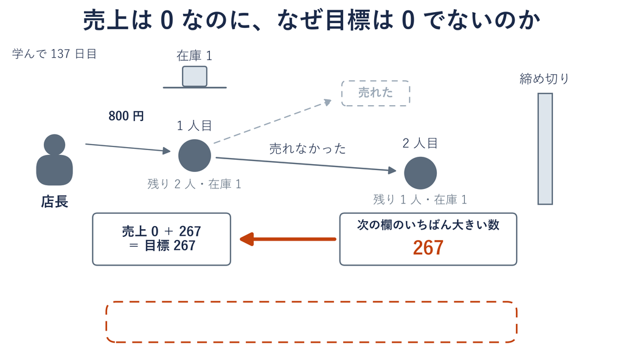

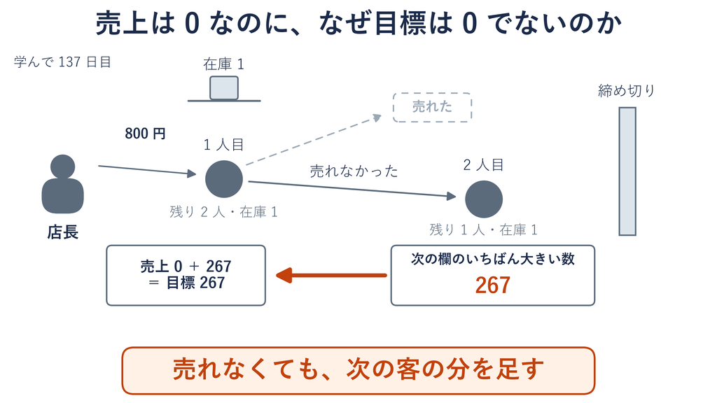

## 更新目標

**更新目標**今回の売上に、次の欄の帳簿のいちばん大きい数を足したもの  
帳簿の欄を直すときに向ける数

今の売上だけの店長 目標 ＝ 今回の売上

次の欄の分も足す店長 目標 ＝ 今回の売上 ＋ 次の欄のいちばん大きい数

次の欄＝次の客が来たときの状態の欄（値段ごとに 2 つ・足すのは大きいほう）  
売れても、在庫と客が残っていれば、同じ式で足す。締め切り・売り切れなら足す数は 0

いちばん大きい数を足す、と決める  
次の客にも、店長はよいほうの値段を見せるつもりだから

## 更新目標の手順

前に出てきた直し方 新しい数 ＝ 古い数 ＋（今回の売上 − 古い数）÷ 見せた回数

手順

①**今回の売上**：売れたら値段、売れなければ 0 円

②**次の欄のいちばん大きい数**：次の場面の 2 つの欄の大きいほう  
締め切り・売り切れなら 0

③**目標へ寄せる**：目標 ＝ ① ＋ ②  
新しい数 ＝ 古い数 ＋（目標 − 古い数）÷ 見せた回数

変えたのは、寄せる先だけ。今回の売上 → 目標

## 手順の例：学んで 2 日目の 2 件

いまの状態（残りの人数, 在庫）

(6, 2) → (5, 1)

[figure not shown]

**(6, 2) 400 円 ○**：目標 ＝ 400 ＋ 次の欄 (5, 1) の 400 ＝ 800。2 回目なので、ずれの 2 分の 1 動いて 600

**(5, 1) 400 円 ○**：次は売り切れなので足すのは 0。目標 400 ＝ 古い数 400 で、動かない

前の数の線と同じ動き  
違うのは、向かう先が「今回の売上」から「目標」に替わった所だけ

## デモ 1 歩ずつの帳簿

数の話

目標 ＝ 今回の売上 ＋ 次の欄のいちばん大きい数  
帳簿は、ずれ ÷ 見せた回数 だけ目標へ寄せる

- **何を見るか**：客が 1 人来るたびに、今の欄 1 つが目標へ寄っていく様子
- **図の意味**：左＝帳簿 24 欄  
  （橙の枠＝今の欄・薄い橙＝次の欄・▲＝いちばん大きい数）・右＝1 回の直しの中身
- **操作**：▶ 1 歩進む・▷ 中身を順に  
  （同じ 1 歩を 6 段に分けて出す）・学んで 1 日目から／137 日目・最初から

ミッション 売れたのに次の欄を足す歩を探し  
その歩の目標がいくつかを確かめる

※ 次のスライドへ進むときは、デモの枠の外を一度クリックしてから ← → キーを押す

[interactive chart not shown]

## (2, 1) で 800 円を見せた 8 件

いまの状態（残りの人数, 在庫）

(2, 1)

前に出てきた目標 目標 ＝ 今回の売上 ＋ 次の欄のいちばん大きい数

|  | 学んで | 売れたか | 売上 | 次の欄 (1, 1) のいちばん大きい数 | 目標 |
| --- | --- | --- | --- | --- | --- |
| ▶ | 72 | ✕ | 0 | まだ 0 | 0 |
| ▶ | 137 | ✕ | 0 | 267 | 267 |
| ▶ | 203 | ○ | 800 | —（売り切れ） | 800 |
|  | 302 | ✕ | 0 | 356 | 356 |
|  | 334 | ○ | 800 | —（売り切れ） | 800 |
|  | 342 | ○ | 800 | —（売り切れ） | 800 |
|  | 348 | ✕ | 0 | 364 | 364 |
| ▶ | 356 | ✕ | 0 | 333 | 333 |

売れた 3 件は 800 円、売れなかった 5 件は次の欄の数が目標

8 件目（学んで 356 日目）は、目標 333 が帳簿 484 より小さいので、帳簿は 465 へ下がる

## 8 件の目標の平均

いまの状態（残りの人数, 在庫）

(2, 1)

[figure not shown]

**8 件の目標の平均**：0 ＋ 267 ＋ 800 ＋ 356 ＋ 800 ＋ 800 ＋ 364 ＋ 333 ＝ 3720 で、3720 ÷ 8 ＝ 465

**帳簿の数**：目標の平均。売れた日と売れなかった日が、起きた回数のとおりに混ざる

足すと 465 円 ＞ 400 円の欄 386 円で、800 円を選ぶ

0 と数えると 300 円。400 円の欄も数え直すと 314 円  
300 円 ＜ 314 円で、400 円を選んでしまう

## Q 学習

**売上に次の欄のいちばん大きい数を足した目標へ、帳簿を寄せる**

定義

**Q 学習**経験の 1 件ごとに、その場面で見せた値段の欄を  
目標（今回の売上 ＋ 次の場面の欄のいちばん大きい数）へ  
ずれ ÷ 見せた回数だけ寄せる学び方

Q は「質（quality）」の頭文字と説明されることが多い  
この場面でこの値段を見せるとどれだけ良いかを書いた帳簿を  
経験で直していくので Q 学習と呼ぶ

- **強化学習**：Q 学習は、試した結果で決め方を直していく学び方の代表
- **2 つの数**：帳簿の数は、試して貯めた平均。  
  前の表の期待値は、割合から計算した数

## Q 学習を 5000 日続けた帳簿

いまの状態（残りの人数, 在庫）

全部の状態

1 歩の直しを、5000 日で 22441 回くり返した。代役は **次の欄の分も足す店長**

[figure not shown]

違うのは (6, 1) の 1 欄だけ（1 度も来ない欄）。(2, 1) は 387 円 ＜ 466 円で 800 円  
466 は、(2, 1) で 800 円を見せた 1978 回の目標の平均

2 人の店長の違いは、この 1 行だけ  
今の売上だけで帳簿をつける店長 `target = r` ｜ 次の欄の分も足す店長 `target = r + best`

## 学んで 2 日目の (6, 2) を 1 欄直す写経

```python
q = learn(1, use_next=True)              # 1 日目まで営業した帳簿
best = max(q[(5, 1)])                    # 次の状態 (5, 1) の大きいほう
target = 400 + best                      # 更新目標＝今回の売上 ＋ best
print(update(q[(6, 2)][0], 2, target))   # (6, 2) の 400 円の欄・2 回目
```

| 行 | 部品 | 中身 | 手順 |
| --- | --- | --- | --- |
| 1 | `learn(1, use_next=True)` | 足して 1 日営業した帳簿 | — |
| 2 | `max(q[(5, 1)])` | 次の欄 (5, 1) の大きいほう（新しい部品） | ② |
| 3 | `400 + best` | 更新目標＝売上 400 ＋ best | ① ＋ ② |
| 4 | `update(…, 2, target)` | 2 回目として目標へ直す （準備のセルの関数） | ③ |

**STEP 1** **＋ コード**でセルを足し、4 行を写して実行。`600.0` を探す  
**STEP 2** 下の【そのまま実行】のセルは写さずに **▶** だけ。  
6 行の値段が 5000 日の表と同じか見る（左が在庫 1・右が在庫 2）

⏸ PAUSE 止めて Colab で写して実行（目安 4 分）。6 行が出たら再生に戻る

## 演習2 学んで 9 日目の 1 件

演習 2

売れなかった 400 円の欄は、いくつに直るか

| 学んで 9 日 目の経験 | 値段 | 売れたか | 次の状態 | 次の欄の 大きい数 | 回数 | 古い数 |
| --- | --- | --- | --- | --- | --- | --- |
| (4, 1) | 400 円 | ✕ | (3, 1) | 400 | 1 回目 | 0 |

1. **書く場所**：段 2 の演習 2 の答え欄  
   （テキストのセルをダブルクリック）
2. **書くこと**：更新目標・直したあとの数  
   0 と数えた場合の数の 3 つ
3. **終わり**：3 つの数が書けたら

⏸ PAUSE 動画を止めて $5$ 分。3 つ書けたら再生に戻る

## 演習2の答え

更新目標

$0 + 400$

$= 400$

売上 0 ＋ 次 (3, 1) の 400

欄を直す

$0 + (400 - 0) \div 1$

$= 400$

1 回目なので目標そのもの

0 と数えると

$0 + (0 - 0) \div 1$

$= 0$

今の売上だけの帳簿

売れなかったのに帳簿は 400 に上がる。次の客の分が残っているから

## まとめ

疑問 売れなかった 800 円の欄は、  
何に向けて直せばよいか

回答 売れなかった 800 円の欄も、売上が無くても  
次の欄の帳簿のいちばん大きい数を  
足した目標へ寄せる  
（売れなくても、次の客の分を足す）

経済プログラミング特論II

第12回・開店 47 日目 — Topic03

表形式Q学習

先の分は、一段ずつしか前へ伝わらない

## 800 円を選ぶまでの日数

前に出てきた直し方のまま 客が 1 人来るたびに、  
見せた値段の欄を 1 つ目標へ寄せる（平均を直す）

足すやり方でつけ始めてからの 10 日では、(2, 1) は 400 円のまま  
帳簿で選ぶ値段がずっと 800 円になるのは？

- **①** あと数日
- **②** あと数十日
- **③** あと数百日

どれになるかは、このあと自分のノートで確かめる

## 6 日分の (6, 2) の 400 円の欄

いまの状態（残りの人数, 在庫）

(6, 2)

(6, 2)＝毎朝の開店の場面（どの日も残り 6 人・在庫 2 から始まる）

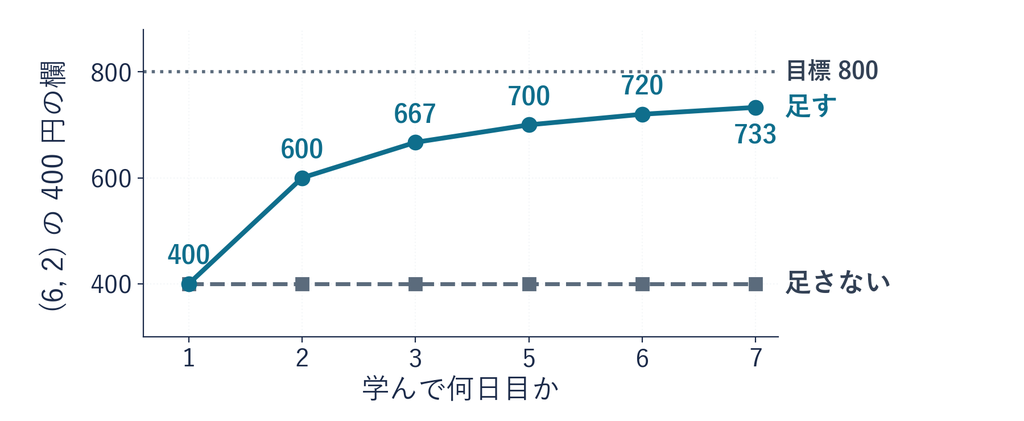

**学んで 1 日目**：(5, 1) の欄はまだ 0 で、目標 400 ＋ 0 ＝ 400・欄は 400

**学んで 2 日目**：目標 400 ＋ 400 ＝ 800 で、(400 ＋ 800) ÷ 2 ＝ 600

学んで 1 日目に (5, 1) が覚えた 400 円が  
学んで 2 日目に (6, 2) へ伝わり、800 円へ近づく

## 学んで 9 日目の営業で直る欄

[figure not shown]

客が 1 人帰るたびに、その場面で見せた値段の欄を 1 つ直す  
ほかの 19 欄は動かない

④ の (3, 1) は ⑤ より先。(2, 1) が覚えた 400 は、④ には間に合わない

## 表形式Q学習

場面と値段の組ごとの表を持ち  
その場面で見せた値段の欄だけを Q 学習で直す

**表形式Q学習**状態（場面）と値段の組ごとに、帳簿の数を表の欄に持ち  
経験の 1 件ごとに、その場面で見せた値段の欄を Q 学習で直し続ける学び方

うちの店なら 残りの人数 6 × 在庫 2 × 値段 2 ＝ 24 欄（店が変われば、欄の数も変わる）

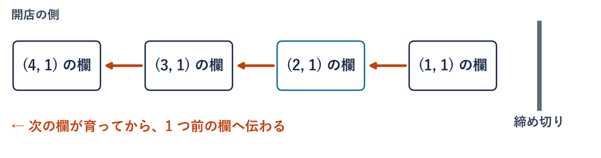

次の欄が育つまで、1 つ前の欄には伝わらない

## 日数のループの写経

```python
for days in [10, 100, 1000, 5000]:      # 営業する日数
    q = learn(days, use_next=True)      # 毎回、学び始めから
    print(days, "日:", higher(q[(2, 1)]))  # (2, 1) の値段
```

| 行 | 部品 | 中身 |
| --- | --- | --- |
| 1 | **① 日数の並び** | 10・100・1000・5000 日を順に days へ |
| 2 | **② 帳簿をつける** | 次の欄の分も足して、days 日ぶんの帳簿 q |
| 3 | **③ 表示** | (2, 1) の欄で平均が高いほうの値段（higher） |

**STEP 1** 段 1 の準備のセルを実行してから、**＋ コード**でセルを足し、3 行を写す  
**STEP 2** **▶** か **Shift + Enter** で実行し、4 行の出力で 800 円に変わる所を探す

⏸ PAUSE 止めて Colab で写して実行（目安 5 分）。4 行が出たら再生に戻る

## 演習3 300 日と 400 日

p.42 の出力 100 日 400 円・1000 日 800 円

演習 3

300 日と 400 日では、どちらの値段を選ぶか

```python
for days in [10, 100, 1000, 5000]:      # ← ここを書き換える
    q = learn(days, use_next=True)      # 毎回、学び始めから
    print(days, "日:", higher(q[(2, 1)]))  # (2, 1) の値段
```

1. **書き換える**：**＋ コード**で足したセルに 3 行を写し  
   1 行目の並びを `[300, 400]` に
2. **確かめる**：どれになるかを、2 行の出力で確かめる  
   （どちらも 400 円／どちらも 800 円／分かれる）
3. **終わり**：2 行が出たら、答え欄に 3 つ書く  
   （答え・300 日の値段・400 日の値段）

⏸ PAUSE 動画を止めて $5$ 分。答え欄に書けたら再生に戻る

## 演習3の答え

| 学んで | 帳簿：400 円の欄 | 帳簿：800 円の欄 | 選ぶ値段 |
| --- | --- | --- | --- |
| 300 日 | 385 | 356 | 400 円 |
| 400 日 | 385 | 490 | 800 円 |

答え：分かれる。300 日は 400 円、400 日は 800 円  
300〜400 日の間で変わった

## 3 つの欄の育ち方

いまの状態（残りの人数, 在庫）

(2, 1)

答えの図：同じ 5000 日を、時間の軸で

[figure not shown]

(2, 1)：1 人目に 800 円で売れなくても、2 人目に 400 円で売れることがある。だから 800 円

(2, 1) の 800 円は、学んで 72 日目に初めて試し、学んで 334 日目が 5 回目  
そこから 5000 日目まで、帳簿で選ぶ値段はずっと 800 円

先の分は学んで 137 日目に届いていた。(2, 1) で高いほうを試す日も少ない

## 4 つの時点の表

いまの状態（残りの人数, 在庫）

(3, 2)

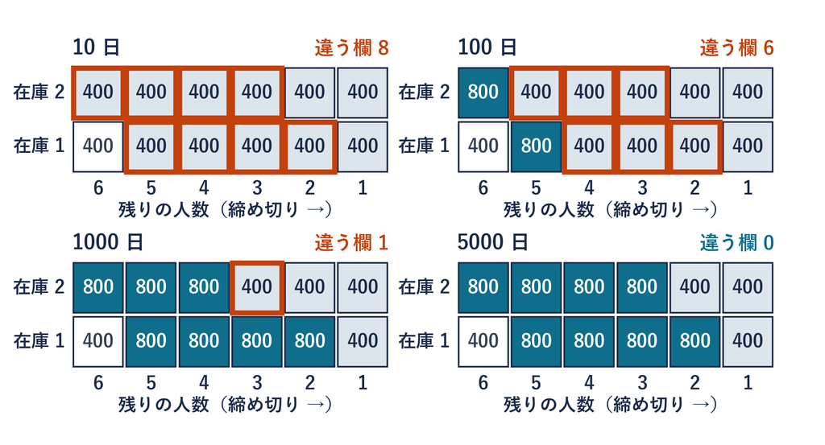

前の回の表と違う欄は 8 → 6 → 1 → 0  
遠い欄が先に 800 円になることもある

## デモ 表形式Q学習を 1 日ずつ

数の話

毎朝 (6, 2) から。客が 1 人帰るたびに、  
その場面で見せた値段の欄 1 つだけを Q 学習で直す

- **何を見るか**：1 日の営業で直る欄（橙の枠・番号は客の順）と、動かない欄（灰色）
- **図の意味**：帳簿 24 欄  
  （残りの人数 6 × 在庫 2 × 値段 2）・下＝今日見せた欄の数と、見せたことのある欄の数
- **操作**：学んだ日数のスライダー・▶ 1 人ずつ・▶ 1 日・▶▶ 10 日・▶▶ 5000 日・最初から

ミッション (2, 1) の 800 円の欄が初めて 0 でなくなる日を  
1 日ずつ（▶▶ 10 日も使って）進めて確かめる

※ 次のスライドへ進むときは、デモの枠の外を一度クリックしてから ← → キーを押す

[interactive chart not shown]

## たどり着けない欄

いまの状態（残りの人数, 在庫）

(6, 1)

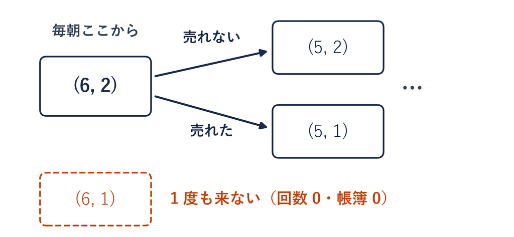

(6, 1)＝残り 6 人・在庫 1。毎朝 (6, 2) から始まるので、1 度も来ない  
回数 0・帳簿 0 のまま。同じなら 400 円を選ぶ

Q 毎朝、帳簿も 0 に戻すのか

戻すのは在庫と残りの人数だけ。帳簿を戻すと**毎日が学び始め**

## まとめ

疑問 次の欄の分も足せば  
何日で (2, 1) は 800 円を選ぶようになるか

回答 答えは三択のいちばん長いほう  
先の分は、次の欄から一段ずつ前へ伝わり  
その日に見せた欄しか直らず、  
高いほうを試す日も少ないから

経済プログラミング特論II

第12回・開店 47 日目 — Topic04

方策の評価

上達は、止めた表の期待値で測る

## 帳簿の数と上達

学んで 1〜20 日で、(6, 2) の帳簿の大きいほうは 400 → 719 円  
この店は、上達したと言えるか

前の回は、店長ごとの期待値で比べた

**止めた表の期待値**学ぶのを止め、値段の表を固定して測った期待値

次のページで、測って確かめる

## 学んで 1〜20 日の帳簿と止めた表の期待値

[figure not shown]

帳簿は 400 → 600 → 667 → 700 → 700 → 719  
値段の表は全欄 400 円のままで、止めた表の期待値は 799.3 円

## 方策の評価

学ぶのを止めて値段の表を固定し、  
その表の期待値を計算すること

**方策の評価**学ぶのも、たまに試すのも止めて方策を固定し  
その方策に従ったときの期待値を計算すること

**方策**状態ごとの値段の決め方（値段の表）

評価するのは、計算機の店の設定を知っている私たち  
店長には渡さない

## 評価の手順

手順

STEP 1**表を止める**：状態ごとに帳簿の大きいほう（同じなら 400 円）

STEP 2**締め切りの側から期待値を埋める**：前の回の埋め方。値段は止めた表のもの

STEP 3**(6, 2) の期待値を読む**：これが止めた表の期待値（毎朝の店の 1 日）

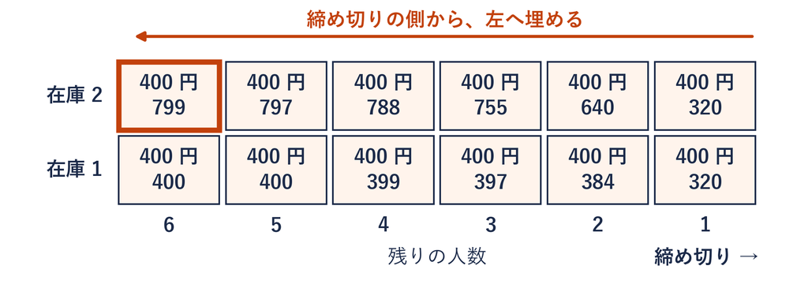

前の回の埋め方と違うのは、「大きいほうを選ぶ」を  
「表の値段を使う」に替えた所だけ

## 学んで 10・100・1000・5000 日

同じ次の欄の分も足す店長を長く営業させ、4 つの時点の表を同じ手順で止めて測る

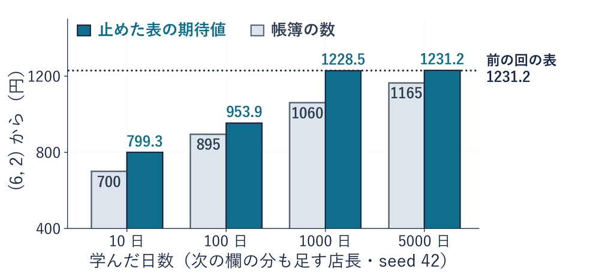

4 つの時点とも、帳簿の数は止めた表の期待値より小さい

学んで 2000 日は 1227.4 円に下がる（いつも上がるとは限らない）

残り 1 人・在庫 2 の欄：400 円なら 400 × 0.8 ＝ 320 で、800 円なら 800 × 0.3 ＝ 240

## 店長ごとの期待値

[figure not shown]

今の売上だけで帳簿をつける店長は、5000 日学んでも  
ずっと 400 円の店長と同じ期待値（799.3 円）

地図の 4 段目の、経験から先を読む店長が、次の欄の分も足す店長

## 使える場面：新人の上達の測り方

✕ 本人の手ごたえで測る

「だいぶ分かってきた」  
という手ごたえが伸びても  
やり方が同じなら  
売上は変わらない

○ やり方を止めて結果で測る

同じ条件で、いまのやり方の  
売上の期待値を出して比べる

手ごたえが伸びても、同じ条件で測った売上が変わらなければ  
上達したとは言えない

## 帳簿と止めた表の期待値を並べる写経

```python
for days in [10, 100, 1000, 5000]:      # 営業する日数
    q = learn(days, use_next=True)      # 毎回、学び始めから
    print(days, "日:", round(max(q[(6, 2)])), round(evaluate(q), 1))
```

| 行 | 部品 | 中身 |
| --- | --- | --- |
| 1 | **① 日数の並び** | 10・100・1000・5000 日を順に days へ（p.42 と同じ） |
| 2 | **② 帳簿をつける** | 次の欄の分も足して、days 日ぶんの帳簿 q（p.42 と同じ） |
| 3 | **③ 2 つの数を表示** | (6, 2) の帳簿の大きいほう（max）と 止めた表の期待値（evaluate）を小数 1 桁（round(…, 1)） |

**STEP 1** 準備のセル（evaluate）を **▶** で実行 **STEP 2** **＋ コード**でセルを足し、3 行を写して実行。  
4 行の出力で、帳簿と止めた表の期待値を比べる

⏸ PAUSE 止めて Colab で写して実行（目安 5 分）。4 行が出たら再生に戻る

## 演習4 seed 7 の客の並び

p.59 の出力（seed 42） 5000 日: 1165 1231.2

演習 4

客の並びと試し方を変えても、  
5000 日で同じ止めた表の期待値に届くか

```python
for days in [10, 100, 1000, 5000]:      # 営業する日数
    q = learn(days, use_next=True)      # ← seed=7, を足す
    print(days, "日:", round(max(q[(6, 2)])), round(evaluate(q), 1))
```

1. **書き換える**：**＋ コード**で足したセルに 3 行を写し  
   2 行目を `learn(days, seed=7, use_next=True)` に
2. **確かめる**：5000 日で 1231.2 円に届くか、出力で見る
3. **終わり**：4 行が出たら、答え欄に書く  
   （届く／届かないと、5000 日の 2 つの数）

⏸ PAUSE 動画を止めて $5$ 分。答え欄に書けたら再生に戻る

## 演習4の答え

| 学んで | seed 7 の帳簿 | seed 7 の 止めた表の期待値 | seed 42 の 止めた表の期待値 |
| --- | --- | --- | --- |
| 10 日 | 728 | 799.3 | 799.3 |
| 100 日 | 993 | 1132.4 | 953.9 |
| 1000 日 | 1091 | 1227.4 | 1228.5 |
| 5000 日 | 1156 | 1231.2 | 1231.2 |

- **答え**：届く。seed 7 も 5000 日で 1231.2 円
- **途中**：客の並びと試し方が違えば、100 日・1000 日の止めた表の期待値は違う
- **値段の表**：前の回と違うのは、1 度も来ない (6, 1) だけ。失敗ではない  
  （(6, 1)：学んだ表では 400 円、前の回の表では 800 円）

4 つの時点とも、帳簿 ＜ 止めた表の期待値  
同じ測り方なので、客の並びが違う店長どうしも比べられる

## まとめ

疑問 帳簿の数が伸びたら、上達したと言ってよいか

回答 帳簿の数だけでは言えない  
上達は、学ぶのを止めて値段の表を固定し、  
その表の期待値で測る

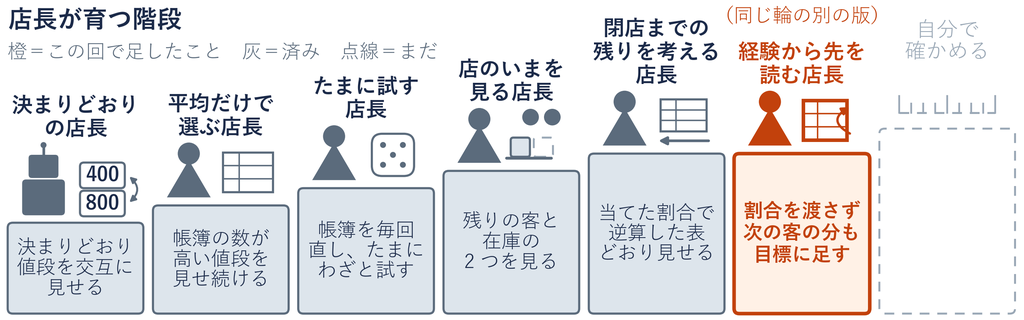

## 今日の 4 つの疑問と回答

|  | 疑問 | 回答 |
| --- | --- | --- |
| T1 | 状態ごとに帳簿を分けて、 今の売上を平均すれば、 前の回の表に届くか | 届かない。今の売上だけでは どの欄も安いほうが上になる |
| T2 | 売れなかった 800 円の欄は、 何に向けて直せばよいか | 売れなくても、次の客の分を足す。 足した目標へ寄せる |
| T3 | 次の欄の分も足せば 何日で (2, 1) は 800 円を選ぶか | 三択のいちばん長いほう。 先の分は一段ずつ前へ伝わる |
| T4 | 帳簿の数が伸びたら、 上達したと言ってよいか | 帳簿の数だけでは言えない。 止めた表の期待値で測る |

## 今日の店の絵と合言葉

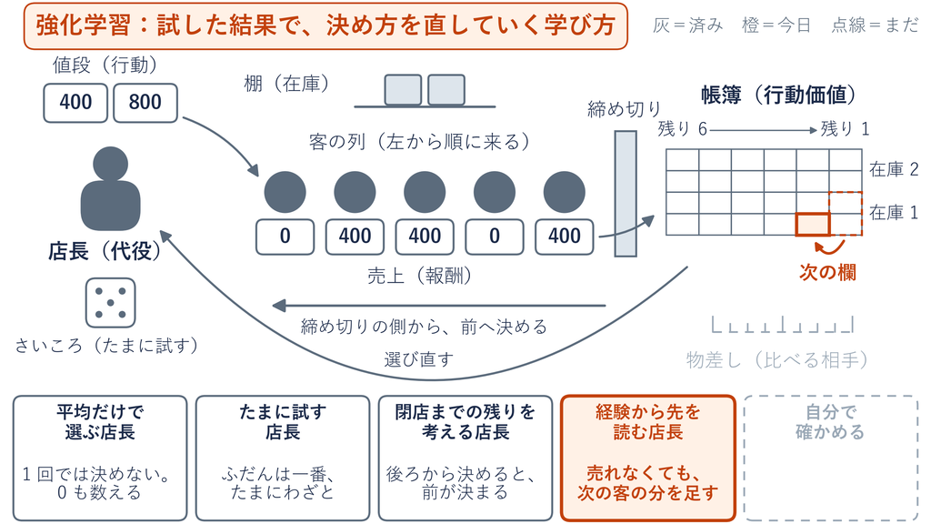

1000 日で止めた表が前の回の期待値に届いたのは：割合を当てて逆算 100 通りすべて／今日の店長 36 通り

やること：演習 1〜4 の答え欄を書いて、いつもの手順で提出